# Power analysis:

bridging theory and practice

Andrés Cruz

UT GOV Methods Workshop, 2024-09-26

## A power crisis?[^1]

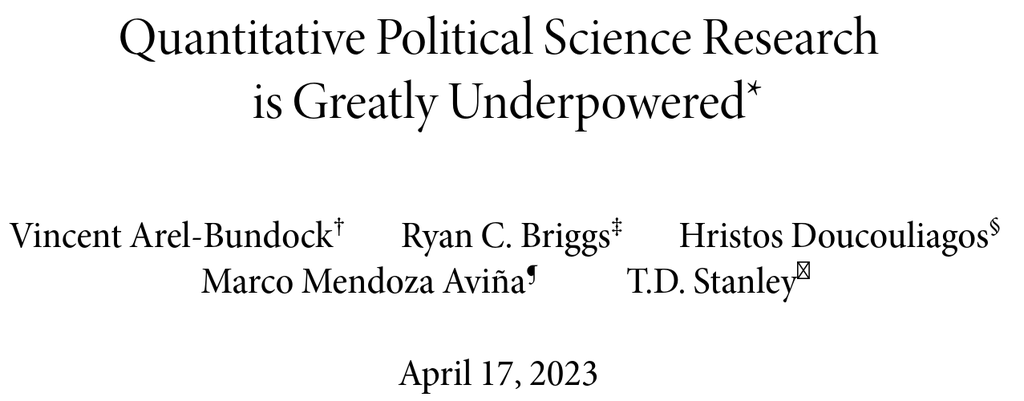

## Why is power analysis important?

1. Low-powered studies are more likely to be unduly optimistic and fail to replicate[^2] [^3] [^4]
2. “Power is for *you*, not for Reviewer Two” –C. Rainey[^5]
   - When getting a null result, you want to be able to distinguish between a true null vs low power
   - We need *justifiable*[^6] and cost-effective sample sizes to get research done

## Outline

- We’ll cover:
  - 🔋 *Theory:* What is power?
  - 🧮 *Mechanics:* How to calculate power?
  - 📚 *Practice:* How to use existing information?

## What is power?

- The probability of rejecting the null hypothesis when it is false
  - This is what we want! Ideally, $Power = 1$.
  - But there are usually practical considerations…

**Example**

One-sided z-test:

$\color{red}{h_0: \mu = 2}$; $\color{blue}{h_1: \mu > 2}$

Consider the specific value of $\color{blue}{\mu_1 = 4}$ in the alternative hyp.

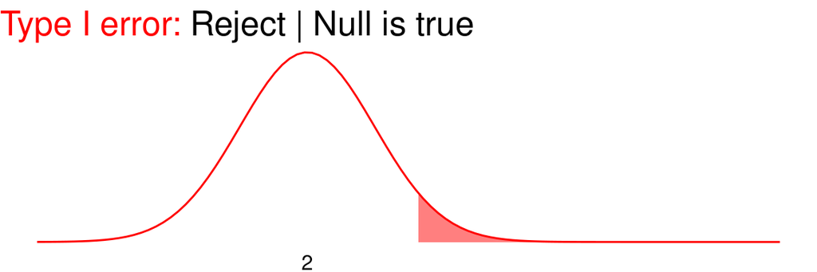

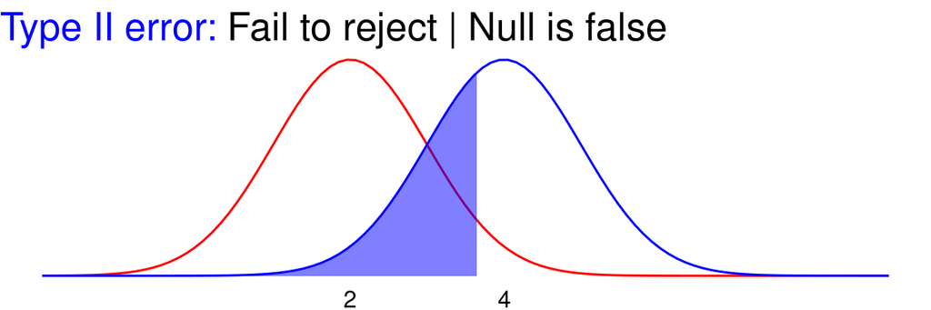

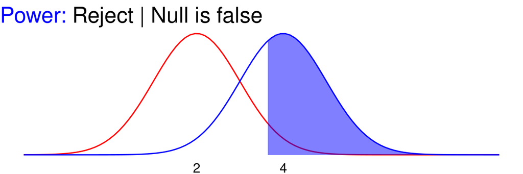

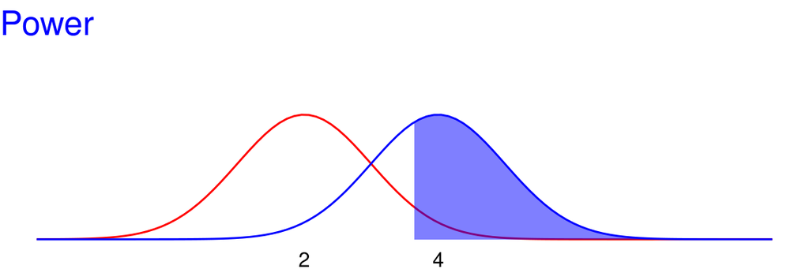

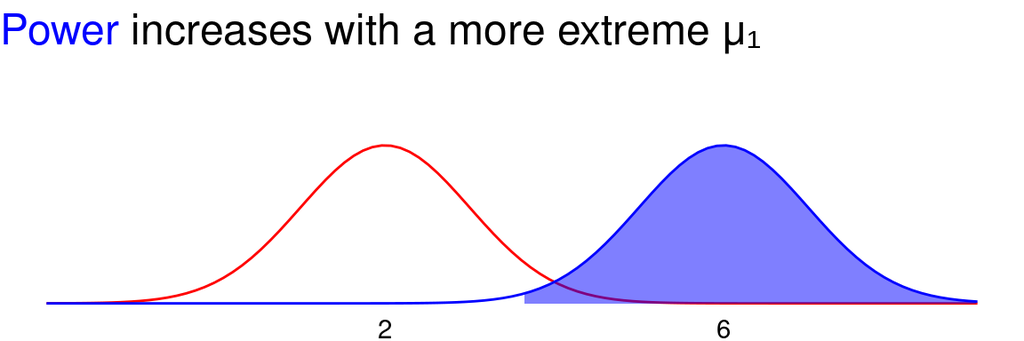

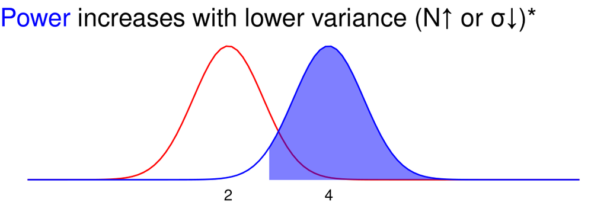

* Sampling distribution: $\bar X \sim N(\mu, \sigma / \sqrt n)$

# Power increases with:

- Stronger hypothesized effects
- Lower population variance
- More observations

## Calculating power analytically (I)

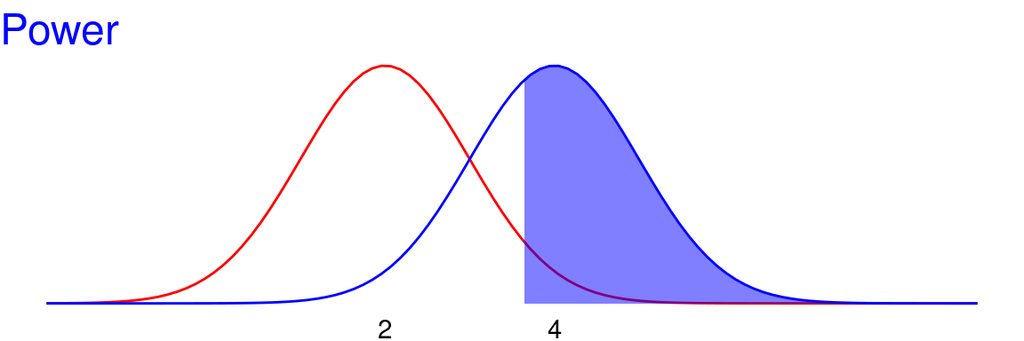

1. Determine threshold for rejection region under $h_0$
2. Calculate shaded probability under $h_1$

## Calculating power analytically (II)

Our ingredients: $\mu_1=4$, $\alpha=.05$, $\sigma=5$, $n=30$.

```r
# get rejection threshold (under h0)
thr <- qnorm(p = .95, mean = 2, sd = 5 / sqrt(30))
# get power (under h1)
1 - pnorm(thr, mean = 4, sd = 5 / sqrt(30))
```

```
[1] 0.7074796
```

```r
pwr::pwr.norm.test(d = (4 - 2) / 5, n = 30,
                   sig.level = 0.05, alternative = "greater")
```

```
     Mean power calculation for normal distribution with known variance

              d = 0.4
              n = 30
      sig.level = 0.05
          power = 0.7074796
    alternative = greater
```

## Calculating power with sims. (I)

```r
# run one million simulations
k <- 1e06

v_rejections <- sapply(1:k, \(i){
  # sample values and take mean (under h1)
  sampled_mean <- rnorm(n = 30, mean = 4, sd = 5) |> mean()
  # check whether this sampled mean is above the rejection threshold
  as.integer(sampled_mean > thr)
})

# get proportion rejected
mean(v_rejections)
```

```
[1] 0.707352
```

## Calculating power with sims. (II)[^7]

```r
library(DeclareDesign)

declaration <-
  declare_model(N = 30, Y = rnorm(n = 30, mean = 4, sd = 5)) +
  declare_test(handler = (\(d) {
    z.test(d$Y, alternative = "greater", mu = 2, sigma.x = 5) |> tidy()
  }))

declaration |> diagnose_designs(sims = 1000)
```

```
Research design diagnosis based on 1000 simulations. Diagnosis completed in 6 secs. Diagnosand estimates with bootstrapped standard errors in parentheses (100 replicates).

      Design N Sims Mean Estimand Mean Estimate Bias SD Estimate RMSE Power
 declaration   1000            NA          3.97   NA        0.90   NA  0.71
 Coverage
       NA
```

## Calculating power (I)

- Analytic approach
  - *Pros:* Fast, off-the-shelf
  - *Cons:* Restricted to some (simple) designs
- Simulations approach
  - *Pros:* Flexible!
  - *Cons:* Slower, harder to code
- For example: power in conjoint experiments can be obtained analytically[^8] or via simulations[^9] [^10]

## Calculating power (II)

- Takeaway: mechanically, calculating power is straightforward **with the necessary ingredients**
  1. Significance level
  2. Sample size
  3. Hypothesized effect
  4. Population variance*
- Can also get required sample size for a given level of power (0.8?[^11])
- The elephant in the room: how to set (3) and (4)?

## Gathering ingredients: variance* (I)

- What we need is information to *anticipate* our standard error
- Sources:
  - Existing or pilot studies[^12] [^13]
  - Estimates of the variance in the population of interest

## Gathering ingredients: variance* (II)[^14]

- For example, if we have a SE from an existing study, we could do $\widehat {SE}_{\text{planned}} = \widehat{SE}_{existing} \times \displaystyle \sqrt \frac{n_{\text{existing}}}{n_{planned}}$.
- If our SE comes from a pilot study, we might want to be more conservative: $\widehat{SE}_{\text{planned}} = \widehat{SE}_{pilot} \times \displaystyle \sqrt \frac{n_{\text{pilot}}}{n_{planned}} \times \displaystyle \Biggl(\displaystyle \sqrt \frac{1}{n_{pilot}} + 1\Biggr)$.
- Using an estimate of the variance of the outcome usually requires stronger assumptions

## Gathering ingredients: hyp. effect

- What should we aim for?
  - When possible, “smallest substantively meaningful effect”[^15]
  - Oftentimes, “expected effect size”[^16]
- Sources
  - Previous studies with similar designs and outcomes
  - Meta-analysis or literature reviews[^17]
  - DO NOT use a pilot study for this[^18] [^19] [^20]
- If unsure, we can always do a sensitivity analysis

## Reasoning with power graphs [^21]

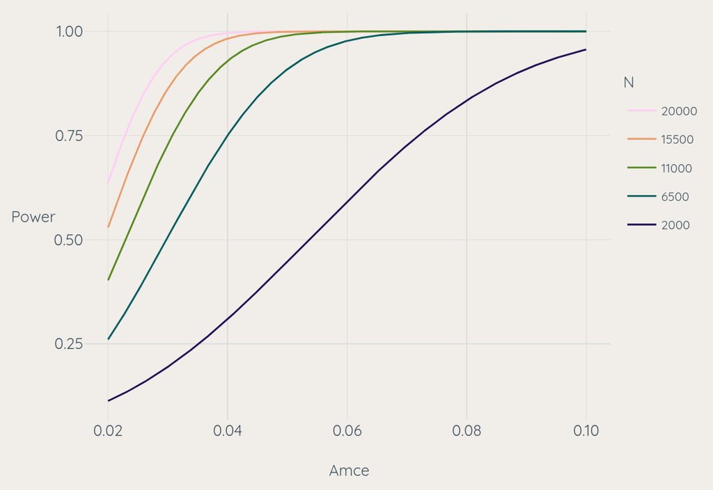

## Takeaway points

- When designing a study, you *want* to run a power analysis
- Use analytical approaches for simple designs and simulation approaches for more complex designs
- Power depends on sample size, significance level, population variance*, and effect size
  - Get info from previous studies, pilots*, or the reference population
- Use (but suspect) rules of thumb. Embrace the trade-offs!

# Thank you!

✉️ <andres.cruz@utexas.edu>

bit.ly/power-gov-methods

## Footnotes

[^1]: Arel-Bundock, Vincent, Ryan C. Briggs, Hristos Doucouliagos, Marco M. Aviña, and T.D. Stanley. 2023. “Quantitative Political Science Research Is Greatly Underpowered.” OSF Preprints. doi:10.31219/osf.io/7vy2f.
[^2]: Gelman, Andrew, and John Carlin. “Beyond power calculations: Assessing type S (sign) and type M (magnitude) errors.” Perspectives on psychological science 9, no. 6 (2014): 641-651. https://doi.org/10.1177/1745691614551642
[^3]: Button, Katherine S., John PA Ioannidis, Claire Mokrysz, Brian A. Nosek, Jonathan Flint, Emma SJ Robinson, and Marcus R. Munafò. “Power failure: Why small sample size undermines the reliability of neuroscience.” Nature Reviews Neuroscience 14, no. 5 (2013): 365-376. https://doi.org/10.1038/nrn3475
[^4]: Tressoldi, Patrizio E. “Replication unreliability in psychology: elusive phenomena or “elusive” statistical power?.” Frontiers in Psychology 3 (2012): 218. https://doi.org/10.3389/fpsyg.2012.00218
[^5]: Rainey, Carlisley. “Power, Part I: Power Is for You, Not for Reviewer Two.” Blog post. 2023. https://www.carlislerainey.com/blog/2023-05-22-power-1-for-you-not-reviewer-2/.
[^6]: Lakens, Daniël. “Sample size justification.” Collabra: Psychology 8, no. 1 (2022): 33267. https://doi.org/10.1525/collabra.33267
[^7]: Blair, Graeme, Alexander Coppock, and Macartan Humphreys. Research design in the social sciences: Declaration, diagnosis, and redesign. Princeton University Press, 2023. https://book.declaredesign.org/
[^8]: Schuessler, Julian, and Markus Freitag. 2020. “Power Analysis for Conjoint Experiments.” SocArXiv. https://doi.org/10.31235/osf.io/9yuhp.
[^9]: Stefanelli, Alberto, and Martin Lukac. 2020. “Subjects, Trials, and Levels: Statistical Power in Conjoint Experiments.” SocArXiv. https://doi.org/10.31235/osf.io/spkcy.
[^10]: Blair, Graeme, Alexander Coppock, and Macartan Humphreys. Research design in the social sciences: Declaration, diagnosis, and redesign. Princeton University Press, 2023. https://book.declaredesign.org/library/experimental-descriptive.html#sec-ch17s3. **Sec. 17.3: Conjoint experiments**.
[^11]: Lakens, Daniël. “Sample size justification.” Collabra: Psychology 8, no. 1 (2022): 33267. https://doi.org/10.1525/collabra.33267
[^12]: Rainey, Carlisle. (2024). “Statistical Power from Pilot Data: Simulations to Illustrate.” Blog post. https://www.carlislerainey.com/blog/2024-06-03-pilot-power/
[^13]: DeclareDesign Team. (2019). “Should a pilot study change your study design decisions?” Blog post. https://declaredesign.org/blog/posts/pilot-studies.html
[^14]: Rainey, Carlisle. 2024. “Power Rules: Practical Statistical Power Calculations.” https://github.com/carlislerainey/power-rules/blob/main/power-rules.pdf
[^15]: Rainey, Carlisle. 2024. “Power Rules: Practical Statistical Power Calculations.” https://github.com/carlislerainey/power-rules/blob/main/power-rules.pdf
[^16]: Lakens, Daniël. “Sample size justification.” Collabra: Psychology 8, no. 1 (2022): 33267. https://doi.org/10.1525/collabra.33267
[^17]: Stefanelli, Alberto, and Martin Lukac. 2020. “Subjects, Trials, and Levels: Statistical Power in Conjoint Experiments.” SocArXiv. https://doi.org/10.31235/osf.io/spkcy.
[^18]: Leon, Andrew C., Lori L. Davis, and Helena C. Kraemer. “The role and interpretation of pilot studies in clinical research.” Journal of psychiatric research 45, no. 5 (2011): 626-629. https://doi.org/10.1016/j.jpsychires.2010.10.008
[^19]: DeclareDesign Team. (2019). “Should a pilot study change your study design decisions?” Blog post. https://declaredesign.org/blog/posts/pilot-studies.html
[^20]: Rainey, Carlisle. (2024). “Statistical Power from Pilot Data: Simulations to Illustrate.” Blog post. https://www.carlislerainey.com/blog/2024-06-03-pilot-power/
[^21]: Schuessler, Julian, and Markus Freitag. 2020. “Power Analysis for Conjoint Experiments.” SocArXiv. https://doi.org/10.31235/osf.io/9yuhp. Created with their online tool: https://markusfreitag.shinyapps.io/cjpowr/.